# 회귀분석

## 변수 유형별 분석 방법

[figure not shown]

## 회귀분석 개념

- 하나 혹은 그 이상의 원인이 종속변수에 미치는 영향을 추적하여 식으로 표현하는 통계기법
- 변수들 사이의 인과관계를 밝히고 모형을 적합하여 관심있는 변수를 예측하거나 추론하기 위해 사용하는 분석 방법
- 독립변수의 개수가 하나인 경우 **단순선형회귀분석**, 독립변수의 개수가 두 개 이상이면 **다중선형회귀분석**으로 분석함

## 단순선형회귀분석

**하나의 독립변수**가 종속변수에 미치는 영향을 추정할 수 있는 통계기법

[figure not shown]

### 선형회귀분석의 가정

- 독립변수와 종속변수 간의 선형성 (선형회귀분석에서 가장 중요한 가정)
- 오차의 정규성 : 오차의 분포가 정규분포를 만족해야 함 **Q-Q plot**, **Shapiro-Wilk**검정 등을 활용하여 정규성 확인
- 오차의 등분산성 : 오차의 분산은 독립변수 값과 무관하게 일정해야 함
- 오차의 독립성 : 예측값의 변화에 따라 오차항이 특정한 패턴을 가지면 안 됨  
  Durbin-Watson 통계량이 2에 가까우면 독립성을 만족  
  Durbin-Watson 통계량이 0에 가까우면 오차항 간에 양의 상관관계가 존재  
  Durbin-Watson 통계량이 4에 가까우면 오차항 간에 음의 상관관계가 존재

[figure not shown]

### 회귀분석 시 검토사항

F 통계량 : 모델 또는 모델 성분의 유의성을 검정하는 분산분석(ANOVA) 방식에 대한 검정 통계량

- **1) 모형이 데이터를 잘 적합하고 있는가** : 모형의 잔차를 그리고 회귀진단을 수행해 판단함
- **2) 회귀모형이 통계적으로 유의한가** :
  - 회귀분석의 결과로 산출되는 F-통계량의 p-value가 유의수준(a)보다 작으면 회귀식이 통계적으로 유의하다고 볼 수 있음
  - H0 : 회귀모형은 유의하지 않다 (𝛽 = 0)  
    H1 : 회귀모형은 유의하다 ( 𝛽는 0이 아니다)
- **3) 모형은 데이터를 얼마나 설명할 수 있는가** : 결정계수(R-square)를 확인함
  - 결정계수는 0~1의 값을 가짐
  - 추정된 회귀식이 전체 데이터에서 설명할 수 있는 데이터의 비율을 의미함 (높을수록 높은 설명력)
  - 다변량 회귀분석의 경우 포함된 독립변수의 유의성에 관계없이 독립변수의 수가 많아지면 결정계수가 높아지는 경향을 보임  
    이를 보완하기 위해 수정된 결정계수(adjusted R square)를 활용하여 모형의 설명력을 판단함
- **4) 모형 내의 회귀계수가 유의한가** : 회귀계수에 대한 t통계량의 p-value가 0.05보다 작으면 회귀계수가 통계적으로 유의하다고 볼 수 있음

#### statsmodels를 이용한 방법

> ols('y ~ x',data=df).fit()
- 모델.summary() : 적합 결과를 요약하여 제시함
- 모델.params : 변수의 회귀계수 (또는 y절편값)
- 모델.resid : 잔차
- 모델.predict(X) : 새로운 데이터에 대한 예측값

**[예제]**

kc_house_data 데이터의 sqft_living(주거공간의 평방 피트)를 독립변수, price를 종속변수로 설정하여 단순 선형 회귀분석을 실시한 후, 추정된 회귀모형에 대해 해석하라

```python
import pandas as pd
import numpy as np
house = pd.read_csv('../data/kc_house_data.csv')
```

```python
house = house[["price","sqft_living"]]
```

```python
## 독립변수와 종속변수의 선형 가정
house.corr()
```

|  | price | sqft_living |
| --- | --- | --- |
| price | 1.000000 | 0.702035 |
| sqft_living | 0.702035 | 1.000000 |

```python
y = house['price']
X = house[['sqft_living']]
```

```python
#pip install statsmodels
from statsmodels.formula.api import ols

# 단순선형회귀모형 적합
lr = ols('price ~ sqft_living',data=house).fit()
```

```python
# 회귀 계수
lr.params
```

```
Intercept     -43580.743094
sqft_living      280.623568
dtype: float64
```

```python
y_pred = lr.predict(X)
y_pred
```

```
0        287555.067025
1        677621.826402
2        172499.404187
3        506441.449985
4        427866.850973
             ...
21608    385773.315789
21609    604659.698749
21610    242655.296161
21611    405416.965541
21612    242655.296161
Length: 21613, dtype: float64
```

```python
resid = y - y_pred
```

```python
#mse
(resid**2).sum()/len(y)
```

```
68351286833.039825
```

```python
## rmse
np.sqrt((resid**2).sum()/len(y))
```

```
261440.79030067177
```

```python
lr.summary()
```

OLS Regression Results

| Dep. Variable: | price | R-squared: | 0.493 |
| --- | --- | --- | --- |
| Model: | OLS | Adj. R-squared: | 0.493 |
| Method: | Least Squares | F-statistic: | 2.100e+04 |
| Date: | Fri, 19 Nov 2021 | Prob (F-statistic): | 0.00 |
| Time: | 05:28:26 | Log-Likelihood: | -3.0027e+05 |
| No. Observations: | 21613 | AIC: | 6.005e+05 |
| Df Residuals: | 21611 | BIC: | 6.006e+05 |
| Df Model: | 1 |  |  |
| Covariance Type: | nonrobust |  |  |

|  | coef | std err | t | P>\|t\| | [0.025 | 0.975] |
| --- | --- | --- | --- | --- | --- | --- |
| Intercept | -4.358e+04 | 4402.690 | -9.899 | 0.000 | -5.22e+04 | -3.5e+04 |
| sqft_living | 280.6236 | 1.936 | 144.920 | 0.000 | 276.828 | 284.419 |

| Omnibus: | 14832.490 | Durbin-Watson: | 1.983 |
| --- | --- | --- | --- |
| Prob(Omnibus): | 0.000 | Jarque-Bera (JB): | 546444.713 |
| Skew: | 2.824 | Prob(JB): | 0.00 |
| Kurtosis: | 26.977 | Cond. No. | 5.63e+03 |

Notes:  
[1] Standard Errors assume that the covariance matrix of the errors is correctly specified.  
[2] The condition number is large, 5.63e+03. This might indicate that there are  
strong multicollinearity or other numerical problems.

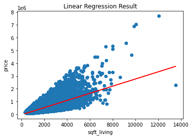

```python
# 회귀모형의 시각화
import matplotlib.pyplot as plt
plt.scatter(X, y) ## 원 데이터 산포도
plt.plot(X, y_pred, color='red') ## 회귀직선 추가

plt.xlabel('sqft_living', fontsize=10)
plt.ylabel('price',fontsize=10)
plt.title('Linear Regression Result')
plt.show()
```

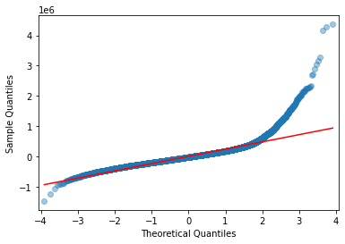

```python
# Q-Q plot
# 잔차가 정규분포를 따르는지 확인

import statsmodels.api as sm

sm.qqplot(resid, line="r", alpha=0.4)
# line은 참조선을 그리는 것으로 '45'(45도 선), 's'(표준화된 라인), 'r'(회귀선), 'q'(사분위수를 통과하는 선) 옵션이 있음
plt.show()
```

**모델 설명**

1) 독립변수는 sqft_living이고 종속변수는 price이다.

2) F-통계량은 2.100e+04이며, F-통계량의 p-value는 0.05보다 매우 작기 때문에 추정된 회귀 모형은 통계적으로 유의하다고 볼 수 있다

3) 결정계수는 0.493로, 이 회귀모형의 데이터에 대한 설명력은 49.3% 이다

4) 상수항과 독립변수의 회귀계수에 대한 p-value가 각각 0.05보다 작으므로 통계적으로 유의하다고 판단할 수 있다

5) 회귀식은 Price = sqft_living * 280.6236 + -43580.743094 와 같이 도출할 수 있다

scikit-learn 머신러닝을 이용한 방법

> sklearn.linear_model.LinearRegression().fit()

LinearRegression() : 선형회귀분석 모델을 생성하는 함수  
fit() : 선형 회귀 모델에 필요한 두 가지 변수(x, y)를 전달

- 설명변수의 차원을 조정해야 함
- R의 summary()와 같은 기능이 없음
- 기울기와 절편을 따로 호출해서 얻을 수 있음
- 잔차를 자동으로 계산해주는 기능이 없음

```python
# fit 함수가 x 값으로 2차원 array를 받으므로 dataframe으로 저장
X = house[['sqft_living']]
y = house['price']
```

```python
#pip install sklearn
from sklearn.linear_model import LinearRegression
lr = LinearRegression() # 회귀모델 생성
lr.fit(X, y) # 회귀모델 학습
```

```
LinearRegression()
```

```python
# 기울기와 절편은 따로 호출하여 확인랑 수 있다
print('기울기 :', lr.coef_)
print('절편 :', lr.intercept_)
```

```
기울기 : [280.6235679]
절편 : -43580.74309447361
```

```python
# 추정된 값을 보기 위해서는 모델.predict(x)를 출력한다

y_pred= lr.predict(X)
y_pred
```

```
array([287555.06702452, 677621.82640197, 172499.40418656, ...,
       242655.29616092, 405416.96554144, 242655.29616092])
```

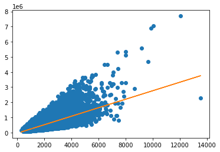

```python
# plot로 확인하는 방법

plt.plot(X, y, 'o')
plt.plot(X, y_pred)
plt.show()
```

```python
# 잔차를 확인하는 방법 : y값과 추정값의 차를 계산
resid = y - y_pred
print('잔차 :\n', resid.values)
```

```
잔차 :
 [ -65655.06702452 -139621.82640197    7500.59581344 ...  159445.70383908
   -5416.96554144   82344.70383908]
```

```python
## R2
lr.score(X,y)
```

```
0.4928532179037931
```

```python
#mse
(resid**2).sum()/len(y)
```

```
68351286833.039825
```

```python
## rmse
np.sqrt((resid**2).sum()/len(y))
```

```
261440.79030067177
```

```python
### 데이터셋이 모델을 잘 적합하는지 검증을 하고 싶다면

from sklearn.model_selection import train_test_split

X_train,X_test,y_train,y_test = train_test_split(X,y,test_size=0.3,random_state=2021)
```

```python
lr.fit(X_train,y_train)
```

```
LinearRegression()
```

```python
y_pred = lr.predict(X_test)
```

```python
resid = y_test - y_pred
```

```python
## R2
lr.score(X_test,y_test)
```

```
0.49761443846972153
```

```python
#mse
(resid**2).sum()/len(y_test)
```

```
227834108933.14154
```

```python
## rmse
np.sqrt((resid**2).sum()/len(y_test))
```

```
477319.71353919746
```